# TP STUDENT_PERFORMANCE GROUPE 06

```python
import numpy as np
import pandas as pd

import seaborn as sns
import matplotlib.pyplot as plt
```

```python
# Importation du dataset

data = pd.read_csv('dataset/StudentsPerformance.csv')
```

```python
data.head()
```

|  | gender | race/ethnicity | parental level of education | lunch | test preparation course | math score | reading score | writing score |
| --- | --- | --- | --- | --- | --- | --- | --- | --- |
| 0 | female | group B | bachelor's degree | standard | none | 72 | 72 | 74 |
| 1 | female | group C | some college | standard | completed | 69 | 90 | 88 |
| 2 | female | group B | master's degree | standard | none | 90 | 95 | 93 |
| 3 | male | group A | associate's degree | free/reduced | none | 47 | 57 | 44 |
| 4 | male | group C | some college | standard | none | 76 | 78 | 75 |

# NETTOYAGES DES DONNEES

```python
#Nous observons qu'il y'a pas de données manquantes dans notre jeu de données
data.info()
```

```
<class 'pandas.core.frame.DataFrame'>
RangeIndex: 1000 entries, 0 to 999
Data columns (total 8 columns):
 #   Column                       Non-Null Count  Dtype
---  ------                       --------------  -----
 0   gender                       1000 non-null   object
 1   race/ethnicity               1000 non-null   object
 2   parental level of education  1000 non-null   object
 3   lunch                        1000 non-null   object
 4   test preparation course      1000 non-null   object
 5   math score                   1000 non-null   int64
 6   reading score                1000 non-null   int64
 7   writing score                1000 non-null   int64
dtypes: int64(3), object(5)
memory usage: 62.6+ KB
```

```python
# Lignes dupliquées aucune alors le dataset est pret pour l'analyse univariée
data.duplicated().sum()
```

```
0
```

# ANALYSE UNIVARIEE AVEC ET SANS GRAPHIQUE

### Observons les différentes modalités dans nos différentes variables

```python
data.nunique()
```

```
gender                          2
race/ethnicity                  5
parental level of education     6
lunch                           2
test preparation course         2
math score                     81
reading score                  72
writing score                  77
dtype: int64
```

```python
data.columns
```

```
Index(['gender', 'race/ethnicity', 'parental level of education', 'lunch',
       'test preparation course', 'math score', 'reading score',
       'writing score'],
      dtype='object')
```

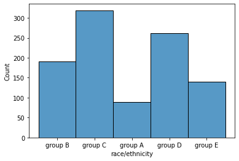

```python
sns.histplot(data=data, x='race/ethnicity')
```

```python
data['race/ethnicity'].value_counts(normalize=True)*100
```

```
group C    31.9
group D    26.2
group B    19.0
group E    14.0
group A     8.9
Name: race/ethnicity, dtype: float64
```

### La race majoriataire est le groupe C(31.9%) et la minoriatire groupe A(8.9%)

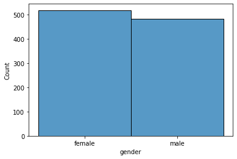

```python
sns.histplot(data=data, x='gender')
```

```python
data['gender'].value_counts(normalize=True) * 100
```

```
female    51.8
male      48.2
Name: gender, dtype: float64
```

### Il y'a plus de femmes(51.8%) que d'hommes(48.2%)

```python
data['parental level of education'].value_counts(normalize=True)*100
```

```
some college          22.6
associate's degree    22.2
high school           19.6
some high school      17.9
bachelor's degree     11.8
master's degree        5.9
Name: parental level of education, dtype: float64
```

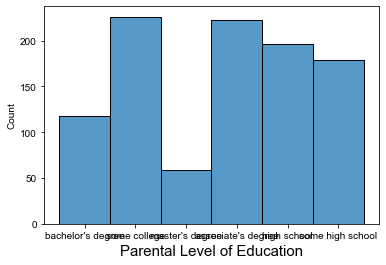

```python
sns.histplot(data=data, x='parental level of education',bins=6)
plt.rcParams['figure.figsize'] = (11,5)
plt.xlabel('Parental Level of Education',fontsize=15)
sns.set_theme()
plt.show()
```

```python
data['parental level of education'].value_counts(normalize=True)*100
```

```
some college          22.6
associate's degree    22.2
high school           19.6
some high school      17.9
bachelor's degree     11.8
master's degree        5.9
Name: parental level of education, dtype: float64
```

### La pluspart des parents ont un niveau d'études college(22.6%) et moins ayant un master(5.9%)

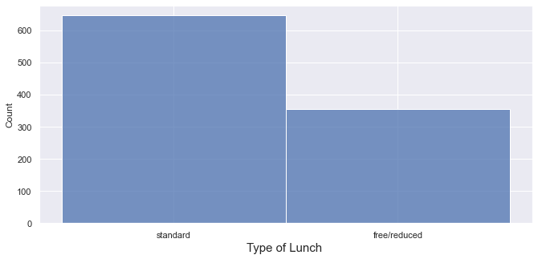

```python
sns.histplot(data=data, x='lunch',bins=6)
plt.rcParams['figure.figsize'] = (4,5)
plt.xlabel('Type of Lunch ',fontsize=15)
sns.set_theme()
plt.show()
```

```python
data['lunch'].value_counts(normalize=True)*100
```

```
standard        64.5
free/reduced    35.5
Name: lunch, dtype: float64
```

### La majorité des étudiants prennent un répas standard(64.5%) et pas vraiment les répas gratuit(35.5%)

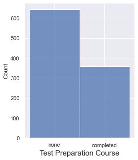

```python
sns.histplot(data=data, x='test preparation course')
plt.rcParams['figure.figsize'] = (5,5)
plt.xlabel('Test Preparation Course',fontsize=15)
sns.set_theme()
plt.show()
```

```python
data['test preparation course'].value_counts(normalize=True)*100
```

```
none         64.2
completed    35.8
Name: test preparation course, dtype: float64
```

```python
data.describe()
```

|  | math score | reading score | writing score |
| --- | --- | --- | --- |
| count | 1000.00000 | 1000.000000 | 1000.000000 |
| mean | 66.08900 | 69.169000 | 68.054000 |
| std | 15.16308 | 14.600192 | 15.195657 |
| min | 0.00000 | 17.000000 | 10.000000 |
| 25% | 57.00000 | 59.000000 | 57.750000 |
| 50% | 66.00000 | 70.000000 | 69.000000 |
| 75% | 77.00000 | 79.000000 | 79.000000 |
| max | 100.00000 | 100.000000 | 100.000000 |

### l'écart type dans la distribution des ces 3 variables est grandes et me pousse a régarder si il existe des valeurs extrêmes ou des outliers

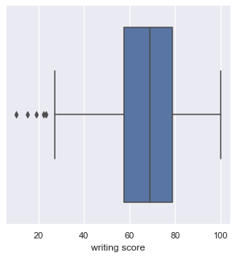

```python
sns.boxplot(data=data, x='writing score')
plt.rcParams['figure.figsize'] = (5,5)
```

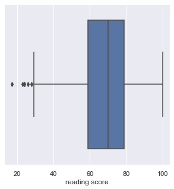

```python
sns.boxplot(data=data, x='reading score')
plt.rcParams['figure.figsize'] = (5,5)
```

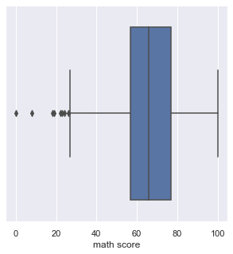

```python
sns.boxplot(data=data, x='math score',orient='h')
plt.rcParams['figure.figsize'] = (5,5)
```

### 'race/ethnicity'

1. La race majoritaire est le groupe C soit(31.9%)
2. La race minoriataire est le groupe A soit (8.9%)

### 'gender'

1. Il ya legèrement plus de femmes que d'hommes
2. Donc le sex n'affecteras pas trop nos observations et on remarques que dans le sens ou on peut dire que les données ne sont pas équilibré (On peut dire que c'est quasiment équilibré)
3. La proportion de sex est equitable soit male(48.2%) et female(51.8%)

### 'parental level of education'

1. La pluspart des parents ont un niveau d'études sois dans un college(22.6%) ou un associates degree (22.2%)
2. Très rares sont les parents qui ont un master (5.9%)

### 'Lunch'

1. La pluspart des élèves prennent un répas de midi standard
2. Plus précisement 35.5% prennent un répas réduit ou gratuit 64.5% prennent un répas standard

### 'test preparation course'

1. La plus part des étudiants n'ont pas fait de cours de préparation avant les examens
2. Nous observons que (64.2%) ne l'ont pas fait mais, (35.8%) ont éffectuer leurs test de préparation avant les examens.

### 'math score'

1. Note min 0 note max 100
2. la std 15 la moyenne 66
3. Il existe des valeurs extrêmes dans cette colonnes, car les données sont centrées entre 57-77 / 100

### 'writing score'

1. min 10 max 100
2. std 15 moyenne 68
3. Il existe des valeurs extrêmes dans cette colonnes, car les données sont centrées entre 57-79 / 100

### 'reading score'

1. min 17 max 100
2. std 14 moyenne 69
3. Il existe des valeurs extrêmes dans cette colonnes, car les données sont centrées entre 59-79 / 100

# ANALYSE BI-VARIEE AVEC ET SANS GRAPHIQUE

```python
data.columns
```

```
Index(['gender', 'race/ethnicity', 'parental level of education', 'lunch',
       'test preparation course', 'math score', 'reading score',
       'writing score'],
      dtype='object')
```

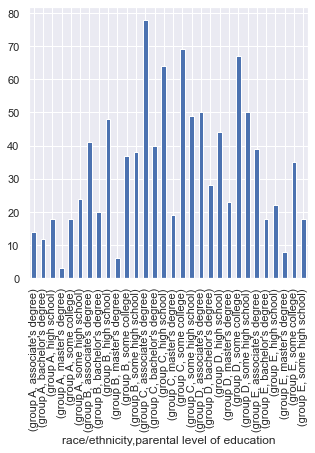

```python
data.groupby(['race/ethnicity','parental level of education']).size().plot(kind='bar')
```

### Des parents qui sont dans le groupe C la pluspart on un diplome de 'associate degree'

### Très rares sont les parents qui ont master et son du groupe A

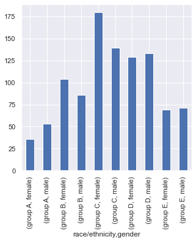

```python
data.groupby(['race/ethnicity','gender']).size().plot(kind='bar')
```

### La grandes majorités des étudiants sont des femmes du groupe C

### Le étudiant minoritaire sont des femmes du groupe A

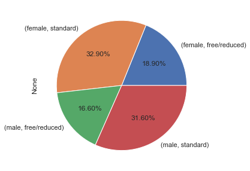

```python
data.groupby(['gender','lunch']).size().plot(kind='pie',autopct='%.2f%%')
```

### Plus de femmes prennent les repas 'free/reduce'

### Plus de femmes prennent les répas standard

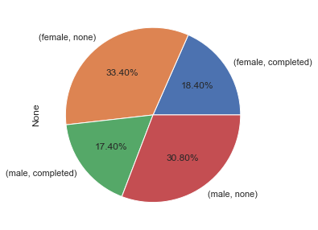

```python
data.groupby(['gender','test preparation course']).size().plot(kind='pie',autopct='%.2f%%')
```

### Plus de femmes termine leur test de préparation et moins hommes

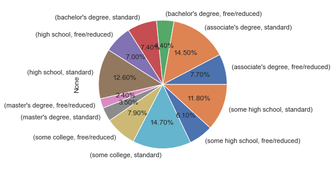

```python
data.groupby(['parental level of education', 'lunch']).size().plot(kind='pie',autopct='%.2f%%')
```

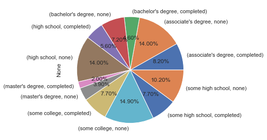

```python
data.groupby(['parental level of education', 'test preparation course']).size().plot(kind='pie',autopct='%.2f%%')
```

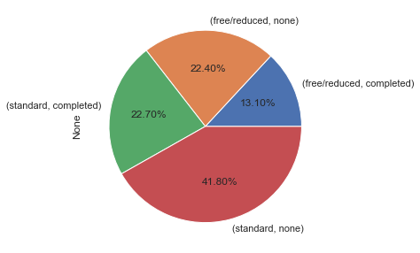

```python
data.groupby(['lunch','test preparation course']).size().plot(kind='pie',autopct='%.2f%%')
```

### la pluspart des étudiant qui prennent un repas standard ne termine pas les test de preparation soit(41.80%)

```
               math score  reading score  writing score
math score       1.000000       0.817580       0.802642
reading score    0.817580       1.000000       0.954598
writing score    0.802642       0.954598       1.000000
```

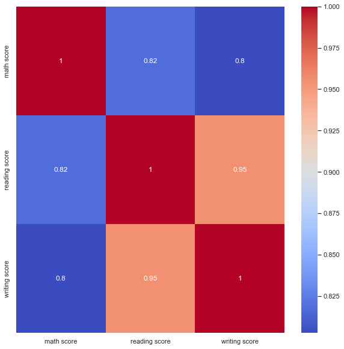

```python
cor_med = data.corr()
print(cor_med)

fig, ax = plt.subplots(figsize=(10,10)) # ligne pour agrandir le plot
sns.heatmap(cor_med, annot=True, cmap ="coolwarm", ax=ax)
```

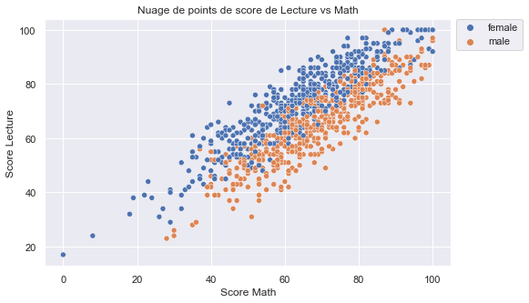

```python
plt.figure(figsize=(8, 5))


sns.scatterplot(data=data, x='math score',y='reading score', hue='gender')
plt.xlabel('Score Math')
plt.ylabel('Score Lecture')
plt.title('Nuage de points de score de Lecture vs Math')
plt.legend(bbox_to_anchor=(1, 1.02))
```

### Les femmes sont plus fortes en reading que les hommes

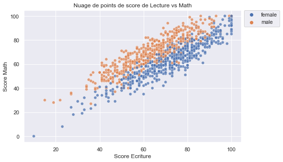

```python
plt.figure(figsize=(8, 5))
sns.scatterplot(data=data, x='writing score',y='math score', hue='gender',alpha=0.75)

plt.xlabel('Score Ecriture')
plt.ylabel('Score Math')
plt.title('Nuage de points de score de Lecture vs Math')

plt.legend(bbox_to_anchor=(1, 1.02))
```

### Les hommes sont plus fortes en math que les femmes

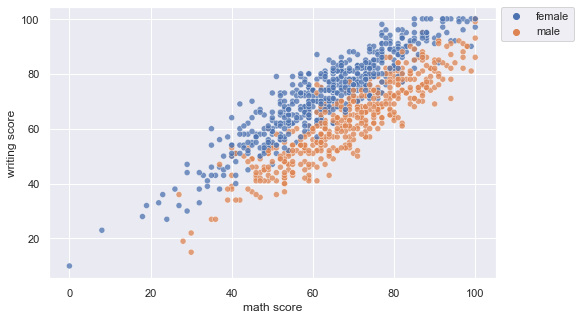

```python
plt.figure(figsize=(8, 5))

sns.scatterplot(data=data, x='math score',y='writing score', hue='gender',alpha=0.75)
plt.legend(bbox_to_anchor=(1, 1.02))
```

### Après avoir éffectuer l'analyse Univariée et Bi-variée avec et sans graphiques nous faisons le constat que nous avons juste les informations sur la proportion et pourcentage des différentes variable.

### Mais il y'a pas vraiment des informations concernant la façon dont les variables catégorielle influences les variables numériques (les notes des étudiants)

### Alors j'ai fais un swarmplot une forme de scatter plot mais qui situe les données exactement la où ça doit être

```
C:\Users\Silva Noelandinho\anaconda3\lib\site-packages\seaborn\categorical.py:1296: UserWarning: 5.1% of the points cannot be placed; you may want to decrease the size of the markers or use stripplot.
  warnings.warn(msg, UserWarning)
```

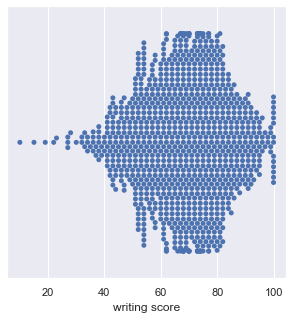

```python
sns.swarmplot(data=data,x='writing score',dodge=True)
plt.rcParams['figure.figsize'] = (5,5)
```

```
C:\Users\Silva Noelandinho\anaconda3\lib\site-packages\seaborn\categorical.py:1296: UserWarning: 7.6% of the points cannot be placed; you may want to decrease the size of the markers or use stripplot.
  warnings.warn(msg, UserWarning)
```

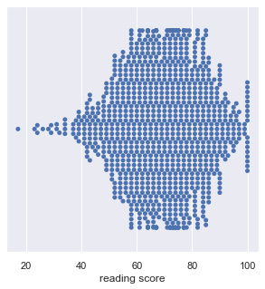

```python
sns.swarmplot(data=data,x='reading score',dodge=True)
plt.rcParams['figure.figsize'] = (5,5)
```

```
C:\Users\Silva Noelandinho\anaconda3\lib\site-packages\seaborn\categorical.py:1296: UserWarning: 8.1% of the points cannot be placed; you may want to decrease the size of the markers or use stripplot.
  warnings.warn(msg, UserWarning)
```

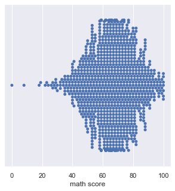

```python
sns.swarmplot(data=data,x='math score',dodge=True)
plt.rcParams['figure.figsize'] = (8,8)
```

1. 0-35 Failed
2. 35-49 Fair
3. 50-64 Passed
4. 66-80 Good
5. 81-90 Very Good
6. 90-100 Excellent

```python
data.describe()
```

|  | math score | reading score | writing score |
| --- | --- | --- | --- |
| count | 1000.00000 | 1000.000000 | 1000.000000 |
| mean | 66.08900 | 69.169000 | 68.054000 |
| std | 15.16308 | 14.600192 | 15.195657 |
| min | 0.00000 | 17.000000 | 10.000000 |
| 25% | 57.00000 | 59.000000 | 57.750000 |
| 50% | 66.00000 | 70.000000 | 69.000000 |
| 75% | 77.00000 | 79.000000 | 79.000000 |
| max | 100.00000 | 100.000000 | 100.000000 |

```python
# Conversion de writing score
data['writing score categ'] = 'Failed'

data.loc[data['writing score'] <= 35, 'writing score categ'] = 'Failed'
data.loc[(data['writing score'] > 35) & (data['writing score'] <= 49), 'writing score categ'] = 'Fair'
data.loc[(data['writing score'] >= 50) & (data['writing score'] <= 64), 'writing score categ'] = 'Passed'
data.loc[(data['writing score'] >= 66) & (data['writing score'] <= 80), 'writing score categ'] = 'Good'
data.loc[(data['writing score'] >= 81) & (data['writing score'] <= 90), 'writing score categ'] = 'Very Good'
data.loc[data['writing score'] >= 90 , 'writing score categ'] = 'Excellent'
```

```python
# Conversion de reading score
data['reading score categ'] = 'Failed'

data.loc[data['reading score'] <= 35, 'reading score categ'] = 'Failed'
data.loc[(data['reading score'] > 35) & (data['reading score'] <= 49), 'reading score categ'] = 'Fair'
data.loc[(data['reading score'] >= 50) & (data['reading score'] <= 64), 'reading score categ'] = 'Passed'
data.loc[(data['reading score'] >= 66) & (data['reading score'] <= 80), 'reading score categ'] = 'Good'
data.loc[(data['reading score'] >= 81) & (data['reading score'] <= 90), 'reading score categ'] = 'Very Good'
data.loc[data['reading score'] >= 90 , 'reading score categ'] = 'Excellent'
```

```python
# Conversion de math score
data['math score categ'] = 'Failed'

data.loc[data['math score'] <= 35, 'math score categ'] = 'Failed'
data.loc[(data['math score'] > 35) & (data['math score'] <= 49), 'math score categ'] = 'Fair'
data.loc[(data['math score'] >= 50) & (data['math score'] <= 64), 'math score categ'] = 'Passed'
data.loc[(data['math score'] >= 66) & (data['math score'] <= 80), 'math score categ'] = 'Good'
data.loc[(data['math score'] >= 81) & (data['math score'] <= 90), 'math score categ'] = 'Very Good'
data.loc[data['math score'] >= 90 , 'math score categ'] = 'Excellent'
```

```python
data.head()
```

|  | gender | race/ethnicity | parental level of education | lunch | test preparation course | math score | reading score | writing score | writing score categ | reading score categ | math score categ |
| --- | --- | --- | --- | --- | --- | --- | --- | --- | --- | --- | --- |
| 0 | female | group B | bachelor's degree | standard | none | 72 | 72 | 74 | Good | Good | Good |
| 1 | female | group C | some college | standard | completed | 69 | 90 | 88 | Very Good | Excellent | Good |
| 2 | female | group B | master's degree | standard | none | 90 | 95 | 93 | Excellent | Excellent | Excellent |
| 3 | male | group A | associate's degree | free/reduced | none | 47 | 57 | 44 | Fair | Passed | Fair |
| 4 | male | group C | some college | standard | none | 76 | 78 | 75 | Good | Good | Good |

```python
data['writing score categ'].value_counts()
```

```
Good         384
Passed       272
Very Good    130
Fair          96
Excellent     78
Failed        40
Name: writing score categ, dtype: int64
```

```python
data['reading score categ'].value_counts()
```

```
Good         373
Passed       283
Very Good    156
Excellent     79
Fair          75
Failed        34
Name: reading score categ, dtype: int64
```

```python
data['math score categ'].value_counts()
```

```
Good         341
Passed       312
Very Good    118
Fair         108
Failed        63
Excellent     58
Name: math score categ, dtype: int64
```

```python
data.columns
```

```
Index(['gender', 'race/ethnicity', 'parental level of education', 'lunch',
       'test preparation course', 'math score', 'reading score',
       'writing score', 'writing score categ', 'reading score categ',
       'math score categ'],
      dtype='object')
```

```python
excellent = data.loc[(data['writing score categ'] == 'Excellent') &
                     (data['reading score categ'] == 'Excellent') &
                     (data['math score categ'] == 'Excellent') ,['gender','race/ethnicity','parental level of education','lunch',
                                                                 'test preparation course','math score', 'reading score',
                                                                 'writing score', 'writing score categ', 'reading score categ','math score categ']]
```

```python
excellent.head()
```

|  | gender | race/ethnicity | parental level of education | lunch | test preparation course | math score | reading score | writing score | writing score categ | reading score categ | math score categ |
| --- | --- | --- | --- | --- | --- | --- | --- | --- | --- | --- | --- |
| 2 | female | group B | master's degree | standard | none | 90 | 95 | 93 | Excellent | Excellent | Excellent |
| 114 | female | group E | bachelor's degree | standard | completed | 99 | 100 | 100 | Excellent | Excellent | Excellent |
| 149 | male | group E | associate's degree | free/reduced | completed | 100 | 100 | 93 | Excellent | Excellent | Excellent |
| 165 | female | group C | bachelor's degree | standard | completed | 96 | 100 | 100 | Excellent | Excellent | Excellent |
| 179 | female | group D | some high school | standard | completed | 97 | 100 | 100 | Excellent | Excellent | Excellent |

```python
print('Taille du dataset Excellent',excellent.shape)
excellent.head()
```

```
Taille du dataset Excellent (28, 11)
```

|  | gender | race/ethnicity | parental level of education | lunch | test preparation course | math score | reading score | writing score | writing score categ | reading score categ | math score categ |
| --- | --- | --- | --- | --- | --- | --- | --- | --- | --- | --- | --- |
| 2 | female | group B | master's degree | standard | none | 90 | 95 | 93 | Excellent | Excellent | Excellent |
| 114 | female | group E | bachelor's degree | standard | completed | 99 | 100 | 100 | Excellent | Excellent | Excellent |
| 149 | male | group E | associate's degree | free/reduced | completed | 100 | 100 | 93 | Excellent | Excellent | Excellent |
| 165 | female | group C | bachelor's degree | standard | completed | 96 | 100 | 100 | Excellent | Excellent | Excellent |
| 179 | female | group D | some high school | standard | completed | 97 | 100 | 100 | Excellent | Excellent | Excellent |

```python
print('Le nombre de étudiants du groupe A = ',data.loc[data['race/ethnicity'] == 'group A',].shape[0])
print('Le nombre de étudiants du groupe B = ',data.loc[data['race/ethnicity'] == 'group B',].shape[0])
print('Le nombre de étudiants du groupe C = ',data.loc[data['race/ethnicity'] == 'group C',].shape[0])
print('Le nombre de étudiants du groupe D = ',data.loc[data['race/ethnicity'] == 'group D',].shape[0])
print('Le nombre de étudiants du groupe E = ',data.loc[data['race/ethnicity'] == 'group E',].shape[0])
```

```
Le nombre de étudiants du groupe A =  89
Le nombre de étudiants du groupe B =  190
Le nombre de étudiants du groupe C =  319
Le nombre de étudiants du groupe D =  262
Le nombre de étudiants du groupe E =  140
```

```
group E    35.714286
group C    25.000000
group D    17.857143
group B    14.285714
group A     7.142857
Name: race/ethnicity, dtype: float64
```

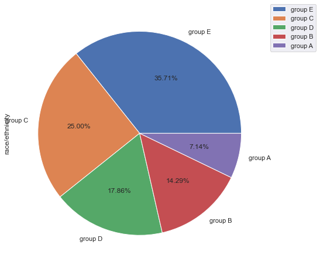

```python
print(excellent['race/ethnicity'].value_counts(normalize=True)*100)
excellent['race/ethnicity'].value_counts(normalize=True).plot(kind='pie',autopct='%.2f%%')
plt.legend(bbox_to_anchor=(1, 1.02))
```

### Les étudiants les plus performants sont du groupe E et les moins performants du groupe A

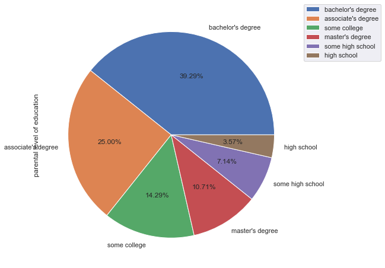

```python
excellent['parental level of education'].value_counts(normalize=True).plot(kind='pie',autopct='%.2f%%')
excellent['parental level of education'].value_counts(normalize=True)*100
plt.legend(bbox_to_anchor=(1, 1.02))
```

### Les étudiants les plus performants ont des parents qui ont un bachelors degree et les moins performantes un niveau d'etudes du lycée

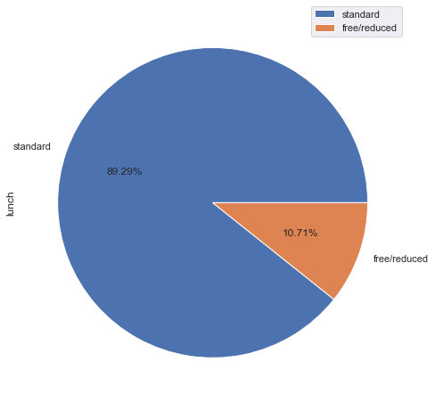

```python
excellent['lunch'].value_counts(normalize=True).plot(kind='pie',autopct='%.2f%%')
excellent['lunch'].value_counts(normalize=True)*100
plt.legend(bbox_to_anchor=(1, 1.02))
```

### Les meilleures étudiants prennent un luch standard soit 89.29%

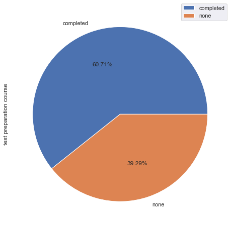

```python
excellent['test preparation course'].value_counts(normalize=True)*100
excellent['test preparation course'].value_counts(normalize=True).plot(kind='pie',autopct='%.2f%%')
plt.legend(bbox_to_anchor=(1, 1.02))
```

### Les meilleures étudiants complètent leurs test de preparation (60.71%)

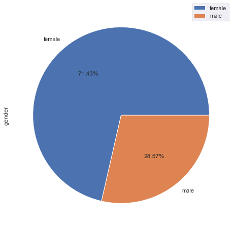

```python
excellent['gender'].value_counts(normalize=True)*100
excellent['gender'].value_counts(normalize=True).plot(kind='pie',autopct='%.2f%%')
plt.legend(bbox_to_anchor=(1, 1.02))
```